# 08-参数估计

主要知识点：

1、点估计：矩估计法

2、区间估计：总体均值的区间估计、总体比例的区间估计、总体方差的区间估计、两个总体均值之差的区间估计、两个总体比例之差的区间估计、两个总体方差比的区间估计

3、样本量的确定：估计总体均值时样本量的确定、估计总体比例时样本量的确定

# 思考题的个人解答

1.解析估计量和估计值  
估计量是描述总体参数的某个统计量就，估计值就是根据某个样本统计量计算得出的值．

2.简述评价估计量好坏的标准．  
主要从无偏性，有效性，一致性描述统计量的好坏．

3.怎么理解置信区间  
置信区间是指多次重复抽样中，所得到的统计区间包含总体参数的比例，而不是概率．

4.解析95%的置信区间．  
意思是抽样一百次，得到的一百个置信区间中，有95个包含总体参数

5.$z_{\alpha/2}\frac {\sigma}{\sqrt{n}}$的含义是什么？  
总体估计均值时的估计误差，指总体均值落在估计均值$z_{\alpha/2}\frac {\sigma}{\sqrt{n}}$两侧的范围内的置信度为$1-{\alpha}$

6.解析独立样本和匹配样本的含义  
独立样本是指从两个不同的总体中抽取的样本，所有元素相互独立．匹配样本是指一个样本中的数据与另一个样本中的数据均一一对应．

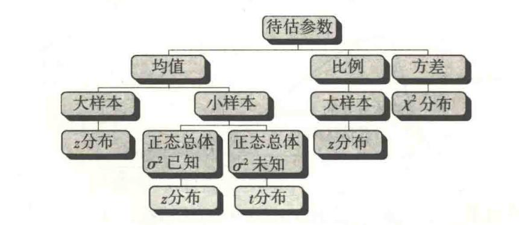

```python
# import base64
# f=open('../source/pics/chapter7/参数估计.jpg','rb') #二进制方式打开图文件
# ls_f=base64.b64encode(f.read()) #读取文件内容，转换为base64编码
# f.close()
# print(ls_f)
```